```r
mydata <- read.csv ("activity.csv", header = TRUE)
dim(mydata)
```

```
## [1] 17568     3
```

Calculating total number of steps taken per day NA values are removed and grouping of data by date to find the total number of steps taken per day

```r
library(dplyr)
```

```r
mydata$date <- as.character(mydata$date)
mydata1 <- na.omit(mydata)
mydata2 <- group_by(mydata1, date)
mydata3 <- summarise(mydata2, Totalsteps=sum(steps))
library(ggplot2)
```

Histogram of total number of steps taken per day calculated using ggplot2 library

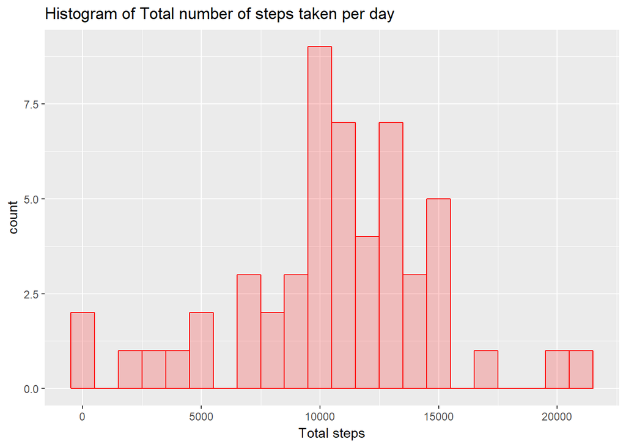

```r
qplot(mydata3$Totalsteps, geom = "histogram", binwidth = 1000, main = "Histogram of Total number of steps taken per day", xlab ="Total steps", fill = I("red"), col = I("red"), alpha = I(.2))
```

```r
mean(mydata3$Totalsteps)
```

```
## [1] 10766.19
```

```r
median(mydata3$Totalsteps)
```

```
## [1] 10765
```

Calculating Activity daily pattern- Grouping of data by interval and average number of steps per interval

```r
mydata4 <- group_by(mydata1, interval)
mydata5 <- summarise(mydata4, Avgsteps = mean(steps))
```

Time series plot of interval on X axis and average number of steps taken, averaged across all days on Y-axis plotted

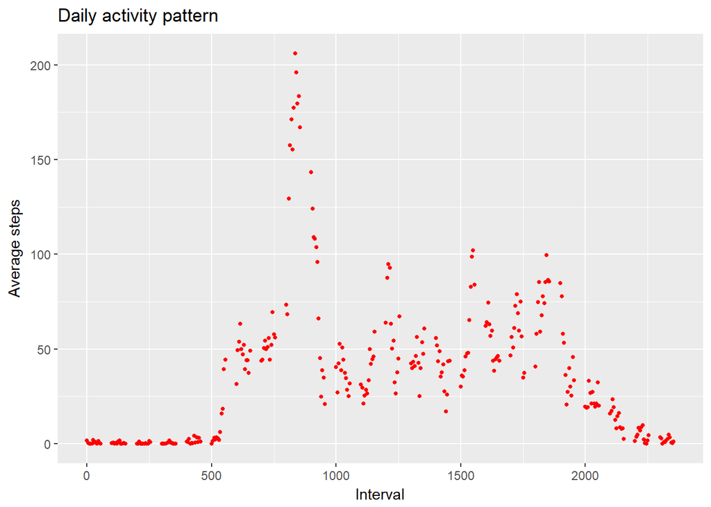

```r
ggplot(mydata5, aes(interval,Avgsteps))+ geom_point(color="red", size=1) + ggtitle("Daily activity pattern") + xlab("Interval") + ylab("Average steps")
```

```r
mydata5[which.max(mydata5$Avgsteps),]
```

```
## # A tibble: 1 x 2
##   interval Avgsteps
##      <int>    <dbl>
## 1      835 206.1698
```

Imputing Missingvalues: Total number of missing values in datatset

```r
nrow(mydata[is.na(mydata$steps), ])
```

```
## [1] 2304
```

Missing values are replaced with mean value of interval

```r
activitydata <- mydata
nadata <- is.na(activitydata$steps)
intervalmean <- tapply(activitydata$steps, activitydata$interval, mean, na.rm=TRUE)
activitydata$steps[nadata] <- intervalmean[as.character(activitydata$interval[nadata])]
names(activitydata)
```

```
## [1] "steps"    "date"     "interval"
```

```r
nrow(activitydata[is.na(activitydata$steps), ])
```

```
## [1] 0
```

```r
activitydata1 <- group_by(activitydata, date)
activitydata2 <- summarise(activitydata1, Totalsteps=sum(steps))
```

Histogram of total number of steps taken each day

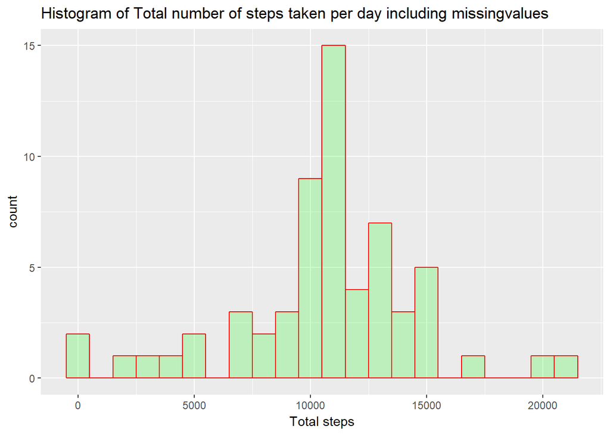

```r
qplot(activitydata2$Totalsteps, geom = "histogram", binwidth = 1000, main = "Histogram of Total number of steps taken per day including missingvalues", xlab ="Total steps", fill = I("green"), col = I("red"), alpha = I(.2))
```

```r
mean(activitydata2$Totalsteps)
```

```
## [1] 10766.19
```

```r
median(activitydata2$Totalsteps)
```

```
## [1] 10766.19
```

The impact of imputing missing data on the estimates of the total daily number of steps is that both mean and Median values are same

Differences in activity patterns between weekdays and weekends

```r
activitydata5 <- activitydata
weekdata1 <- mutate(activitydata5,weektype = (ifelse((weekdays(as.Date(activitydata5$date))=="Saturday"|weekdays(as.Date(activitydata5$date))=="Sunday"), "Weekend", "Weekday")))
head(weekdata1)
```

```
##       steps       date interval weektype
## 1 1.7169811 2012-10-01        0  Weekday
## 2 0.3396226 2012-10-01        5  Weekday
## 3 0.1320755 2012-10-01       10  Weekday
## 4 0.1509434 2012-10-01       15  Weekday
## 5 0.0754717 2012-10-01       20  Weekday
## 6 2.0943396 2012-10-01       25  Weekday
```

```r
Interval2 <- group_by(weekdata1, interval, weektype)
weekdaydata<-summarise(Interval2, Avgsteps = mean(steps, na.rm=TRUE))
head(weekdaydata)
```

```
## # A tibble: 6 x 3
## # Groups:   interval [3]
##   interval weektype   Avgsteps
##      <int>    <chr>      <dbl>
## 1        0  Weekday 2.25115304
## 2        0  Weekend 0.21462264
## 3        5  Weekday 0.44528302
## 4        5  Weekend 0.04245283
## 5       10  Weekday 0.17316562
## 6       10  Weekend 0.01650943
```

Time series plot of the 5-minute interval (x-axis) and the average number of steps taken, averaged across all weekday days or weekend days (y-axis).

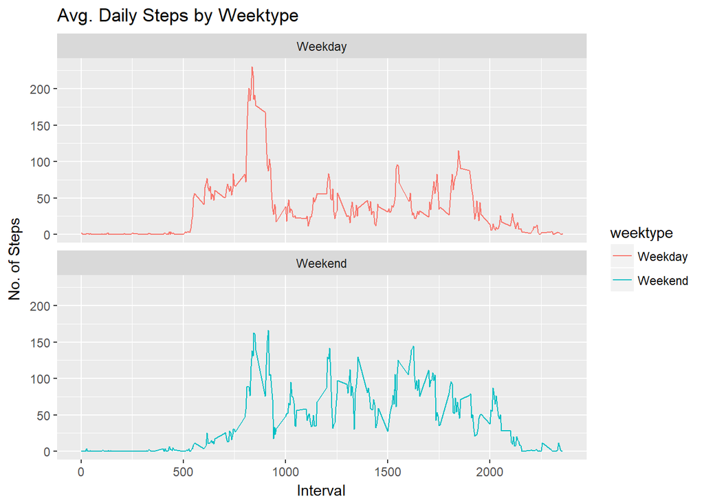

```r
plot <- ggplot(weekdaydata, aes(x =interval , y=Avgsteps, color=weektype)) +geom_line() +labs(title = "Avg. Daily Steps by Weektype", x = "Interval", y = "No. of Steps") + facet_wrap(~weektype, ncol = 1, nrow=2)
print(plot)
```

During the weekday, the object is more active ealier in the day but the object is more active throughout the weekends.